# NSynth Dataset

[NSynth](https://magenta.tensorflow.org/datasets/nsynth#files) is "*a large-scale and high-quality dataset of annotated musical notes*"  
[Download](https://magenta.tensorflow.org/datasets/nsynth#files) train, validation, and test data

```python
import numpy as np
import pandas as pd
import os
import glob
import librosa
import librosa.display
import re
import seaborn as sns
import matplotlib.pyplot as plt
import scipy
import time
import collections
import itertools
from sklearn.model_selection import train_test_split
from sklearn.preprocessing import MinMaxScaler
from sklearn.naive_bayes import GaussianNB
from sklearn.metrics import confusion_matrix
from sklearn.metrics import f1_score
```

```python
print('numpy version ',np.__version__)
print('pandas version ',pd.__version__)
print('librosa version ', librosa.__version__)
print('re version ', re.__version__)
print('seaborn verrsion ', sns.__version__)
print('scipy version ', scipy.__version__)
```

```
numpy version  1.15.4
pandas version  0.23.4
librosa version  0.6.2
re version  2.2.1
seaborn verrsion  0.9.0
scipy version  1.1.0
```

# Instruments & Sources

### Instrument index

| Index | ID |
| --- | --- |
| 0 | bass |
| 1 | brass |
| 2 | flute |
| 3 | guitar |
| 4 | keyboard |
| 5 | mallet |
| 6 | organ |
| 7 | reed |
| 8 | string |
| 9 | synth_lead |
| 10 | vocal |

### Source Index

| Index | ID |
| --- | --- |
| 0 | acoustic |
| 1 | electronic |
| 2 | synthetic |

```python
#Store class names in array
class_names=['bass', 'brass', 'flute', 'guitar',
             'keyboard', 'mallet', 'organ', 'reed',
             'string', 'synth_lead', 'vocal']
#Store source names in array
source_names=['acoustic', 'electronic', 'synthetic']
```

# Anatomy of a Wave File

Explore the features of a wave file by picking random samples for each instrument and illustrating the features

### Pick a file

```python
class_names
```

```
['bass',
 'brass',
 'flute',
 'guitar',
 'keyboard',
 'mallet',
 'organ',
 'reed',
 'string',
 'synth_lead',
 'vocal']
```

```python
#Pick a random  wave file from the dataset
bass_file = '/Users/nadimkawwa/Desktop/Udacity/MLEND/Capstone/nsynth-valid/audio/bass_electronic_018-047-075.wav'
brass_file = '/Users/nadimkawwa/Desktop/Udacity/MLEND/Capstone/nsynth-valid/audio/brass_acoustic_006-031-050.wav'
flute_file = '/Users/nadimkawwa/Desktop/Udacity/MLEND/Capstone/nsynth-valid/audio/flute_synthetic_000-035-127.wav'
guitar_file = '/Users/nadimkawwa/Desktop/Udacity/MLEND/Capstone/nsynth-valid/audio/guitar_acoustic_010-086-100.wav'
keyboard_file = '/Users/nadimkawwa/Desktop/Udacity/MLEND/Capstone/nsynth-valid/audio/keyboard_acoustic_004-041-100.wav'
mallet_file = '/Users/nadimkawwa/Desktop/Udacity/MLEND/Capstone/nsynth-valid/audio/mallet_acoustic_056-065-050.wav'
organ_file = '/Users/nadimkawwa/Desktop/Udacity/MLEND/Capstone/nsynth-valid/audio/organ_electronic_007-015-100.wav'
reed_file ='/Users/nadimkawwa/Desktop/Udacity/MLEND/Capstone/nsynth-valid/audio/reed_acoustic_023-042-127.wav'
string_file = '/Users/nadimkawwa/Desktop/Udacity/MLEND/Capstone/nsynth-valid/audio/string_acoustic_012-035-100.wav'
synth_lead_file = '/Users/nadimkawwa/Desktop/Udacity/MLEND/Capstone/nsynth-valid/audio/flute_acoustic_002-093-075.wav'
vocal_file = '/Users/nadimkawwa/Desktop/Udacity/MLEND/Capstone/nsynth-valid/audio/vocal_synthetic_003-030-050.wav'
```

```python
sample_files = [bass_file, brass_file, flute_file, guitar_file, keyboard_file,
         mallet_file, organ_file, reed_file, string_file, synth_lead_file, vocal_file]
```

### Waveform & Sampling Rate: [librosa.core.load](https://librosa.github.io/librosa/generated/librosa.core.load.html)

A sound is a continous time signal that is usually represented by a wave **form**, this continuous signal is sampled and converted into a discrete time signal. **Sample Rate** is the number of samples of audio recorded per second. The sample rate determines the maximum audio frequency that can be reproduced, Indeed the maximum frequency that can be represented is half the sample rate. Most humans can hear sounds in the frequency of 20-20,000Hz and so most some sounds like CDs are sampled are 44,000Hz, that is to say in one second the analog signal is sampled 44,100.

Sources:  
[Frequency Range of Human Hearing](https://hypertextbook.com/facts/2003/ChrisDAmbrose.shtml)  
[7 Questions About Sample Rate](https://www.sweetwater.com/insync/7-things-about-sample-rate/)

```python
#load the audio as waveform y
#store the sampling rate as s
# To preserve the native sampling rate of the file, use sr=None
y= []
sr = []
for file in sample_files:
    y_out, sr_out = librosa.load(file, sr=None)
    y.append(y_out)
    sr.append(sr_out)
for instrument, y_out, sr_out in zip(class_names, y, sr):
    print("{} has {} samples with a sampling rate of {}".format(instrument, np.size(y_out), sr_out))
```

```
bass has 64000 samples with a sampling rate of 16000
brass has 64000 samples with a sampling rate of 16000
flute has 64000 samples with a sampling rate of 16000
guitar has 64000 samples with a sampling rate of 16000
keyboard has 64000 samples with a sampling rate of 16000
mallet has 64000 samples with a sampling rate of 16000
organ has 64000 samples with a sampling rate of 16000
reed has 64000 samples with a sampling rate of 16000
string has 64000 samples with a sampling rate of 16000
synth_lead has 64000 samples with a sampling rate of 16000
vocal has 64000 samples with a sampling rate of 16000
```

### Harmonic & Percussive Component: [librosa.effects.hpss](https://librosa.github.io/librosa/generated/librosa.effects.hpss.html)

A **percussion** instrument is simply instruments that you can bang on! Think of drums, gongs, xylophones, triangles, etc... A **harmonic** instrument is instrument that produces a series of sounds within which the fundamental frequency of each of them is an integral multiple of the lowest fundamental frequency. For harmonic instruments think of guitars, violions, trumpets, etc...

Sources:  
[Percussion Instruments](https://ccrma.stanford.edu/CCRMA/Courses/152/percussion.html)  
[IEV ref 801-30-04](http://www.electropedia.org/iev/iev.nsf/display?openform&ievref=801-30-04)

```python
len(y[0])
```

```
64000
```

```python
y_harmonic= []
y_percussive= []

for sample in y:
    y_harmonic.append(librosa.effects.hpss(sample)[0])
    y_percussive.append(librosa.effects.hpss(sample)[1])
```

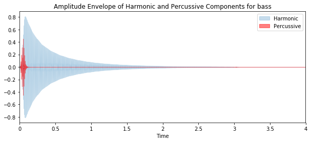

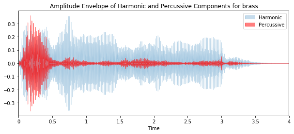

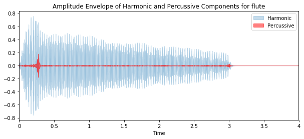

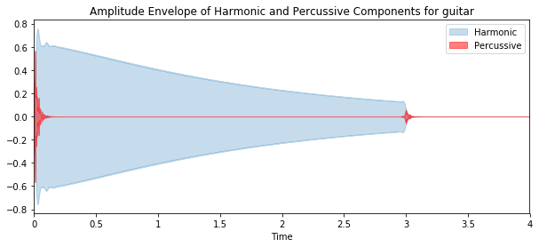

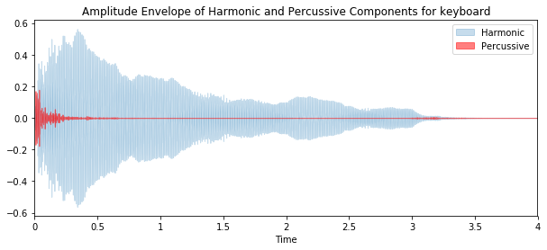

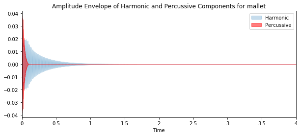

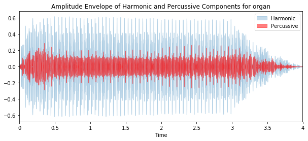

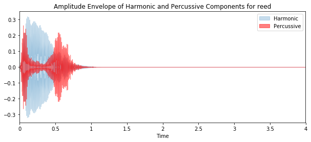

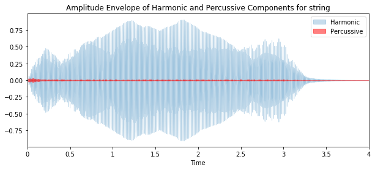

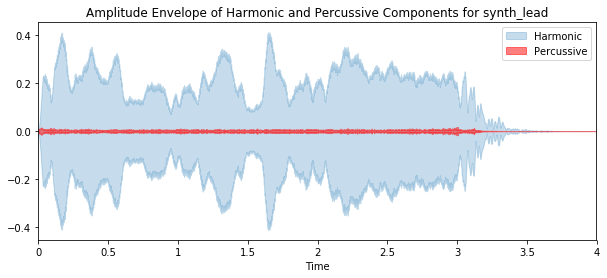

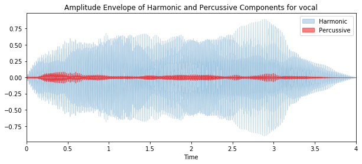

```python
for i, j  in enumerate(y):
    plt.figure(figsize=(10,4))
    librosa.display.waveplot(y_harmonic[i], sr=sr[i], alpha=0.25)
    librosa.display.waveplot(y_percussive[i], sr=sr[i], color='r', alpha=0.5)
    plt.legend(['Harmonic', 'Percussive'])
    plt.title("Amplitude Envelope of Harmonic and Percussive Components for " + class_names[i])
    plt.savefig('plots/soundsAsArrays_'+str(class_names[i])+'.png')



plt.show()
```

### Beat & Tempo: [librosa.beat.beat_track](https://librosa.github.io/librosa/generated/librosa.beat.beat_track.html)

The **tempo** is the rate of speed of a musical piece or passage indicated by one of a series of directions (such as largo, presto, or allegro) and often by an exact metronome marking.  
Source:  
[Merriam Webster](https://www.merriam-webster.com/dictionary/tempo)

```python
tempo, beat_frames = librosa.beat.beat_track(y=y[0], sr=sr[0])
print("Tempo ", tempo)
print("Beat frames ", beat_frames)
```

```
Tempo  156.25
Beat frames  [3]
```

Since we have a single note there's no such thing as a tempo.

### Chroma Energy: [librosa.feature.chroma_cens](https://librosa.github.io/librosa/generated/librosa.feature.chroma_cens.html)

Two pitches are perceived as similar in “color” if they differ by an octave. Based on this observation, a pitch can be separated into two components, which are referred to as tone height and chroma. Assuming the equal-tempered scale, the **chromas** correspond to the set {C, C♯, D, . . . , B} that consists of the twelve pitch spelling attributes as used in Western music notation. Thus, a chroma feature is represented by a 12 dimensional vector:  
x = (x(1), x(2), ..., x(12))T  
Where x(1) corresponds to chroma C, x(2) to chroma C# and so on. In the feature extraction step, a given audio signal is converted into a sequence of chroma features each expressing how the short-time energy of the signal is spread over the twelve chroma bands.

Source:  
[Meinard Müller and Sebastian Ewert Chroma Toolbox: MATLAB implementations for extracting variants of chroma-based audio features In Proceedings of the International Conference on Music Information Retrieval (ISMIR), 2011.](http://ismir2011.ismir.net/papers/PS2-8.pdf)

```python
chromas = []
for y_, sr_ in zip(y, sr):
    chromas.append(librosa.feature.chroma_cens(y=y_, sr=sr_))
```

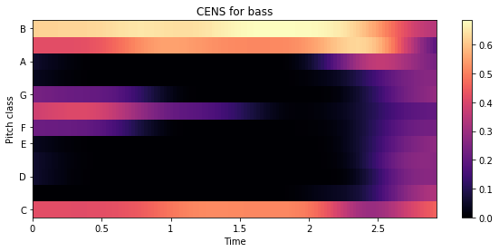

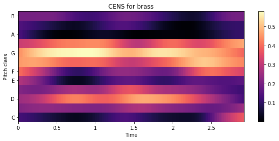

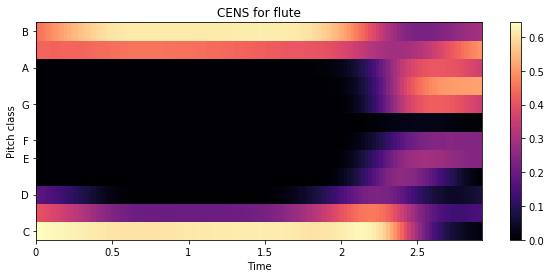

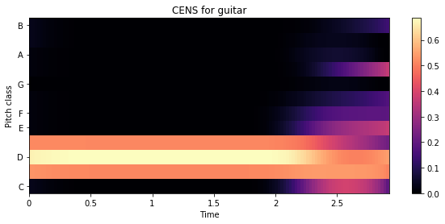

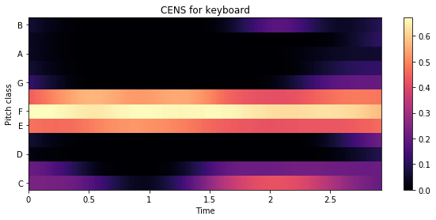

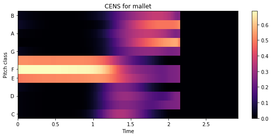

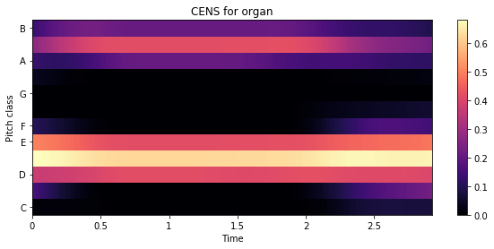

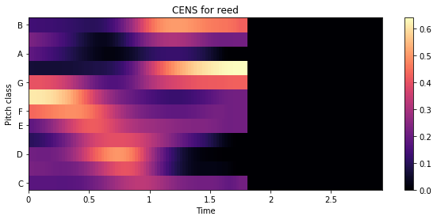

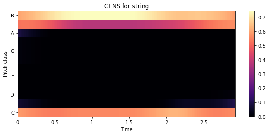

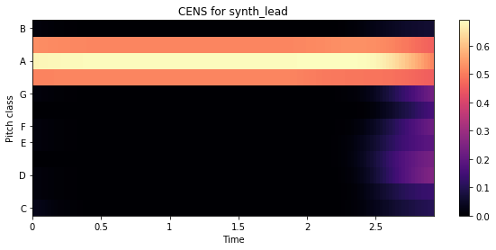

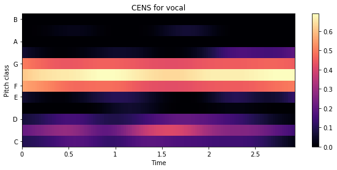

```python
for chroma, instrument, i in zip(chromas,class_names, range(len(class_names))):
    plt.figure(figsize=(10,4))
    librosa.display.specshow(chroma, y_axis='chroma', x_axis='time')
    plt.colorbar()
    plt.title("CENS for " + instrument)
    plt.savefig('plots/ChromaEnergy_'+str(class_names[i])+'.png')

plt.show()
```